# 12 - Time Series

2023-09-25

Caso seja a primeira vez, delete o “eval=FALSE” do chunk abaixo.

```r
df_2016_2022 <- read_csv("data/DFwithHourandLocation.csv")
df_2023 <- read_csv("data/2023-DF.csv")
df_merged <- rbind(df_2016_2022, df_2023)
df_merged
write.csv(df_merged, file = "data/2016-2023-raw-csv.csv", row.names = FALSE)
```

Após isso, passei o “2016-2023-raw-csv.csv” no 00-Cleaner para que possa começar as análises das séries temporais.

```r
df <- read_csv("data/2016-2023-cleaned-csv.csv")
df
```

Vou selecionar os jogadores do top 10 para fazer a analise das série temporais deles, depois vou expandir a ideia para o resto dos jogadores.

```r
top10 <- read_csv("data/top10.csv")

df_top10 <- subset(df, Name %in% top10$Player)
```

Agora plottando as séries temporais deles.

```r
# Crie um diretório para salvar os gráficos individuais, se desejado
dir.create("graficos_individuais", showWarnings = FALSE)

for (jogador in top10$Player) {
  # Filtrar o dataframe apenas para o jogador atual
  df_jogador <- subset(df, Name == jogador)

  # Criar o gráfico de série temporal para o jogador atual
  p <- ggplot(df_jogador, aes(x = date, y = PTS)) +
    geom_line() +
    labs(x = "Data do Jogo", y = "Pontos (PTS)") +
    ggtitle(paste("Série Temporal de PTS para", jogador))

  # Salvar o gráfico individualmente (opcional)
  ggsave(filename = paste("graficos_individuais/", jogador, ".png", sep = ""), plot = p)

  # Imprimir o gráfico na tela (opcional)
  print(p)
}
```

Minha ideia é de criar uma espécie personalizada de data: numero do jogo na season - mes da season - ano da season. Preciso entender melhor como isso vai performar dentro da TimeSeries, se colocar apenas numero do jogo - ano da season vai ser melhor.

Antes disso, vou passar o df “data/2016-2023-cleaned-csv.csv” no pre-processamento do WTP, para ter as colunas que quero testar no arimaX, usando exogenous = Colunas do WTP.

Vou manter as colunas originais do df, pensando em fazer uma multivariate timeseries para ter vários valores sobre a performance do jogador por jogo.

```r
df_wtp <- read_csv("data/2016-2023-wtp.csv")
df_wtp
```

```
## # A tibble: 216,404 × 61
##    Name     MP    FG   FGA  `3P` `3PA`    FT   FTA   ORB   DRB   TRB   AST   STL
##    <chr> <dbl> <dbl> <dbl> <dbl> <dbl> <dbl> <dbl> <dbl> <dbl> <dbl> <dbl> <dbl>
##  1 andr…  37.2     6    16     0     0     6    10     8    11    19     3     1
##  2 marc…  37.1     6    19     1     4     5     6     5     5    10     4     0
##  3 kent…  37.0     7    14     4     7     3     3     1     3     4     1     1
##  4 ersa…  34.4     6    12     3     6     1     2     3     4     7     3     0
##  5 regg…  32.1     4    10     2     4     5     5     1     7     8     5     2
##  6 stan…  24.5     3    10     1     3     0     0     3     1     4     3     0
##  7 stev…  15.9     1     6     1     5     0     0     0     0     0     4     1
##  8 jodi…  11.0     1     4     0     0     0     0     1     1     2     0     0
##  9 aron…  10.8     3     5     0     0     0     0     1     4     5     0     0
## 10 paul…  36       7    15     2     6     3     4     1     7     8     3     0
## # ℹ 216,394 more rows
## # ℹ 48 more variables: BLK <dbl>, TOV <dbl>, PF <dbl>, PTS <dbl>, BPM <dbl>,
## #   opp <chr>, team <chr>, home <dbl>, season <dbl>, date <date>,
## #   season_month <dbl>, hour_float <dbl>, rest_days <dbl>, L10_FG <dbl>,
## #   L5_FG_opp <dbl>, L10_FGA <dbl>, L5_FGA_opp <dbl>, L10_3P <dbl>,
## #   L5_3P_opp <dbl>, L10_3PA <dbl>, L5_3PA_opp <dbl>, L10_FT <dbl>,
## #   L5_FT_opp <dbl>, L10_FTA <dbl>, L5_FTA_opp <dbl>, L10_ORB <dbl>, …
```

```r
player_name <- "nikola_jokic"
```

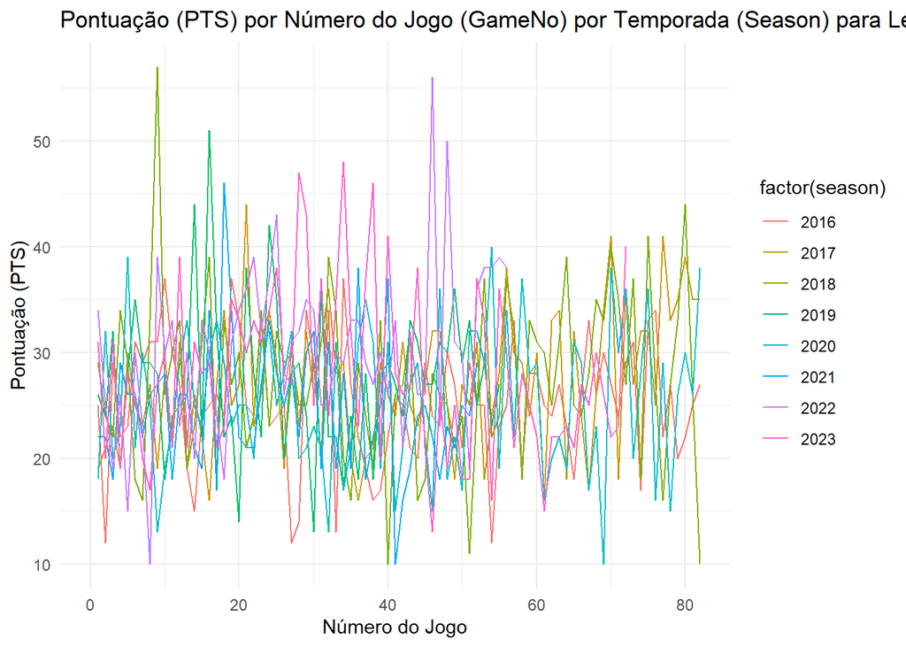

```r
df_lebron <- df_wtp %>%
  filter(Name == "lebron_james")

df_lebron <- df_lebron %>%
  group_by(season) %>%
  mutate(GameNo = row_number()) %>%
  ungroup()

ggplot(df_lebron, aes(x = GameNo, y = PTS, color = factor(season))) +
  geom_line() +
  labs(title = "Pontuação (PTS) por Número do Jogo (GameNo) por Temporada (Season) para Lebron James",
       x = "Número do Jogo",
       y = "Pontuação (PTS)") +
  theme_minimal() +
  xlim(0, 82)  # Define o limite do eixo X entre 0 e 82 jogos que é a quantidade de jogos em uma season excluindo playoff e play-in
```

Ficou muito dificil de entender o gráfico, olhando a principio me parece um gráfico de Noise stationary, vou plotar ano a ano para ter uma visão melhor.

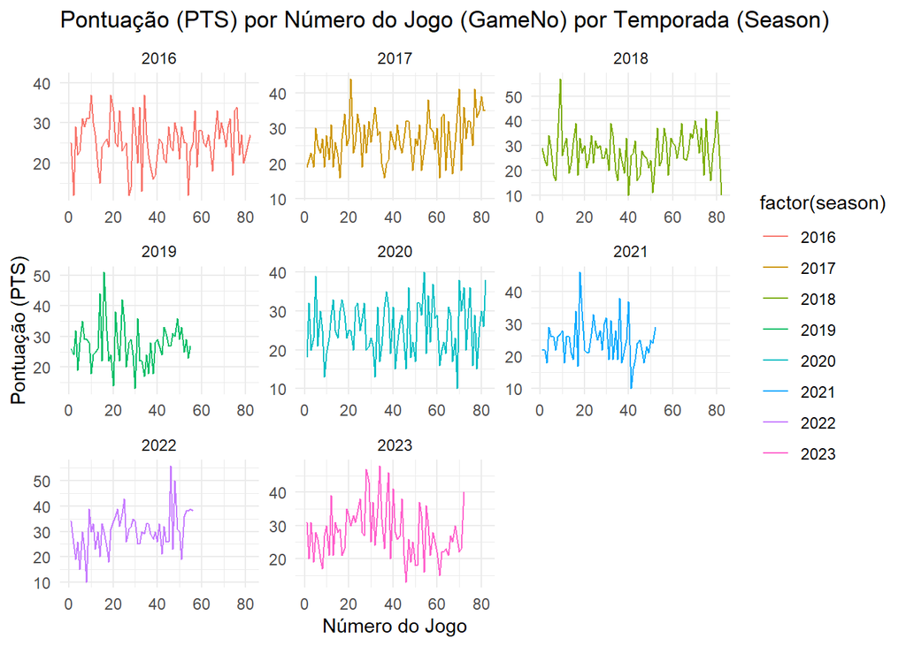

```r
ggplot(df_lebron, aes(x = GameNo, y = PTS, color = factor(season))) +
  geom_line() +
  labs(title = "Pontuação (PTS) por Número do Jogo (GameNo) por Temporada (Season)",
       x = "Número do Jogo",
       y = "Pontuação (PTS)") +
  theme_minimal() +
  xlim(0, 82) +  # Define o limite do eixo X entre 0 e 82 jogos
  facet_wrap(~ season, scales = "free")  # Cria um gráfico para cada temporada
```

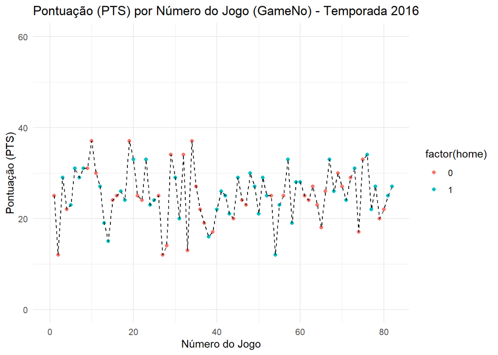

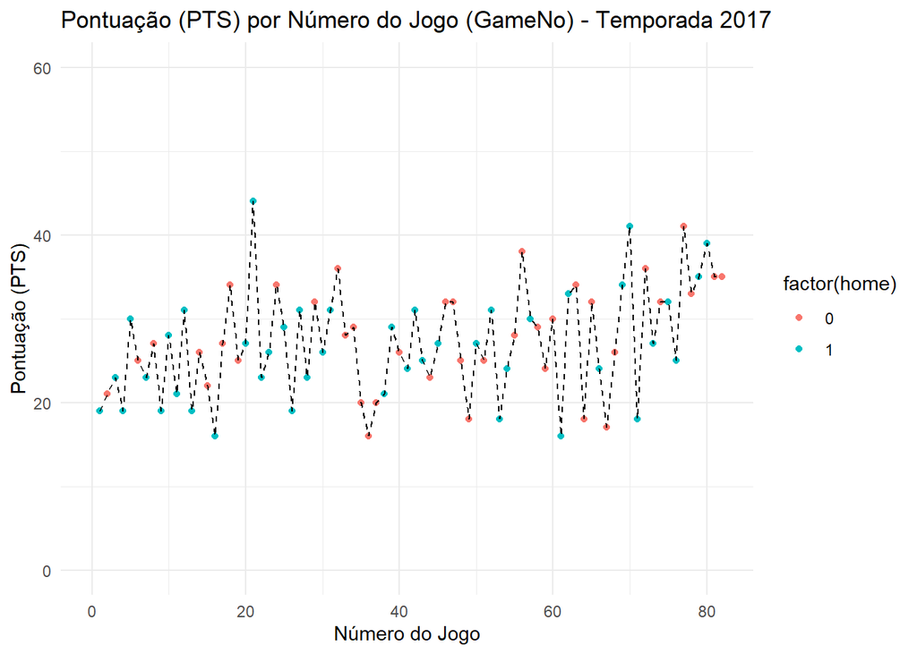

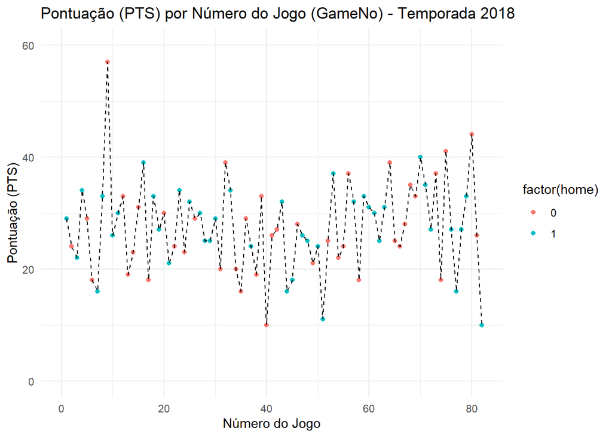

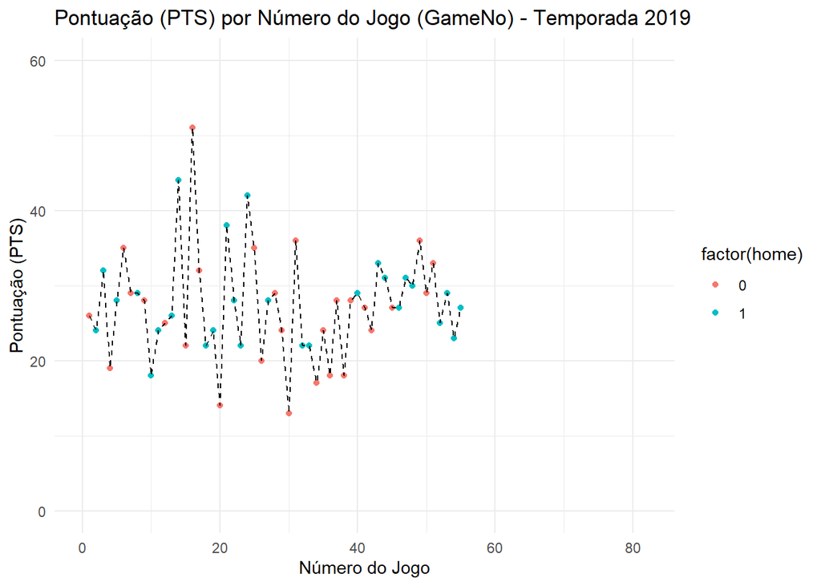

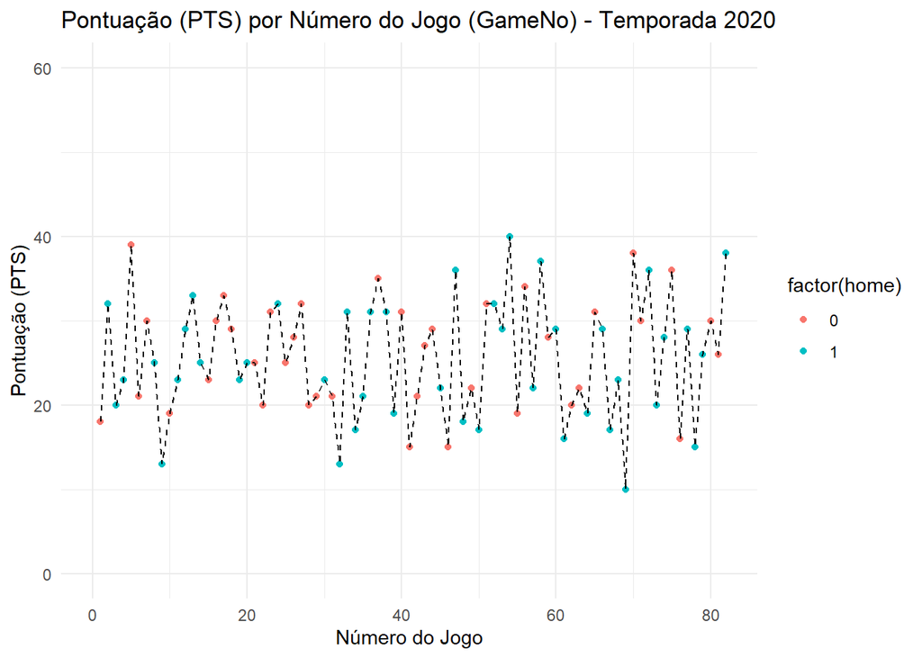

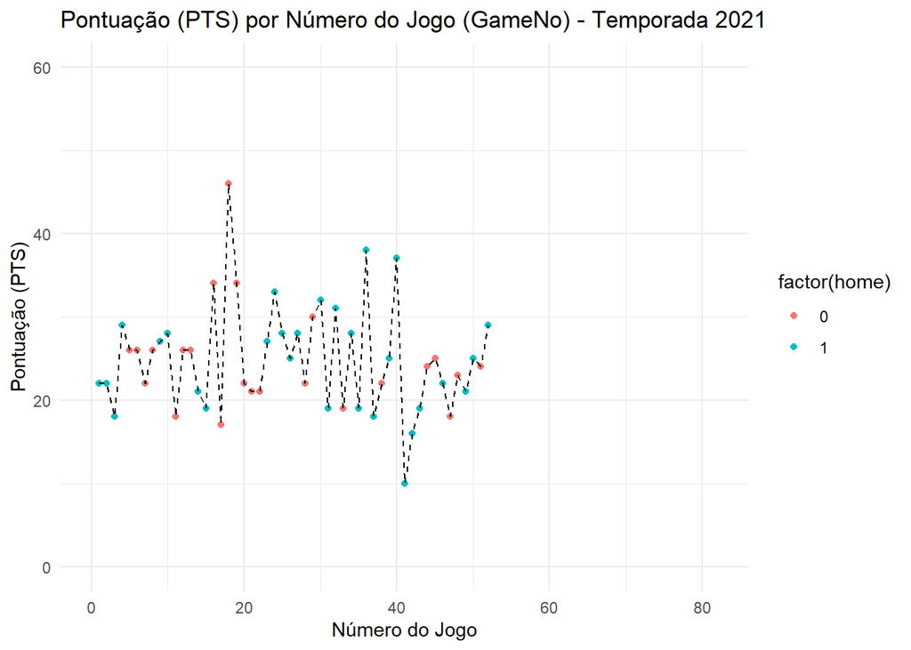

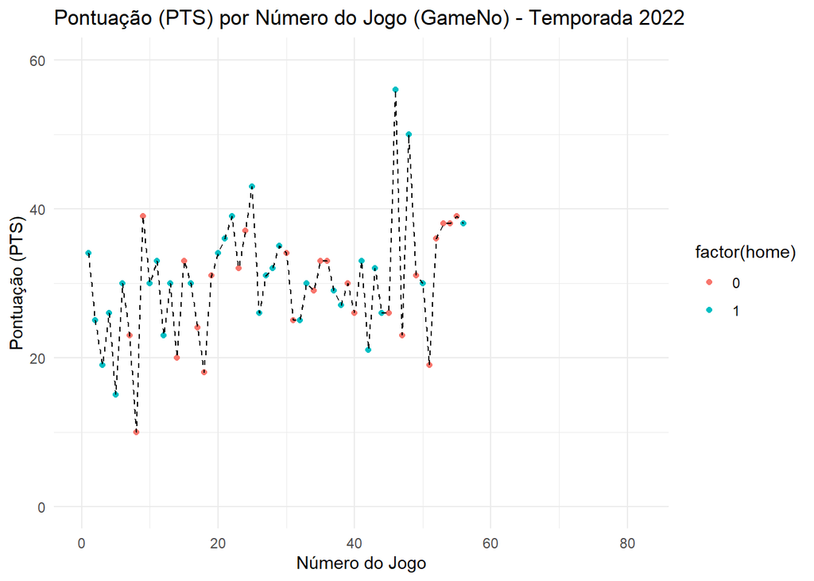

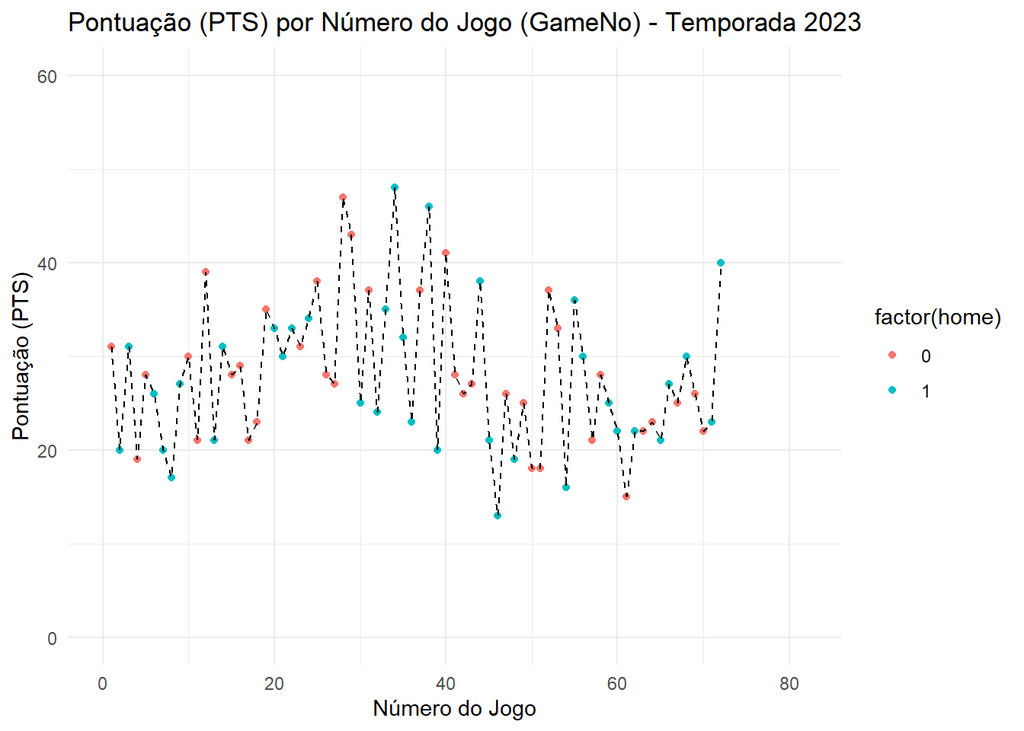

```r
unique_seasons <- unique(df_lebron$season)


for (s in unique_seasons) {
  # Use suppressWarnings para evitar que os warnings sejam impressos
  suppressWarnings({
    p <- ggplot(df_lebron %>% filter(season == s), aes(x = GameNo, y = PTS)) +
      geom_point(aes(color = factor(home))) +
      geom_line(aes(group = 1), linetype = "dashed") +
      labs(title = paste("Pontuação (PTS) por Número do Jogo (GameNo) - Temporada", s),
           x = "Número do Jogo",
           y = "Pontuação (PTS)") +
      theme_minimal() +
      xlim(0, 82) +
      ylim(0,60)

    print(p)
  })
}
```

Testando as bibliotecas xts forecast para modelos de time series. “Before we start using black-box deep learning models to solve the temperatureprediction problem, let’s try a simple, common-sense approach. It will serve as a sanity check, and it will establish a baseline that we’ll have to beat to demonstrate the usefulness of more-advanced machine learning models”

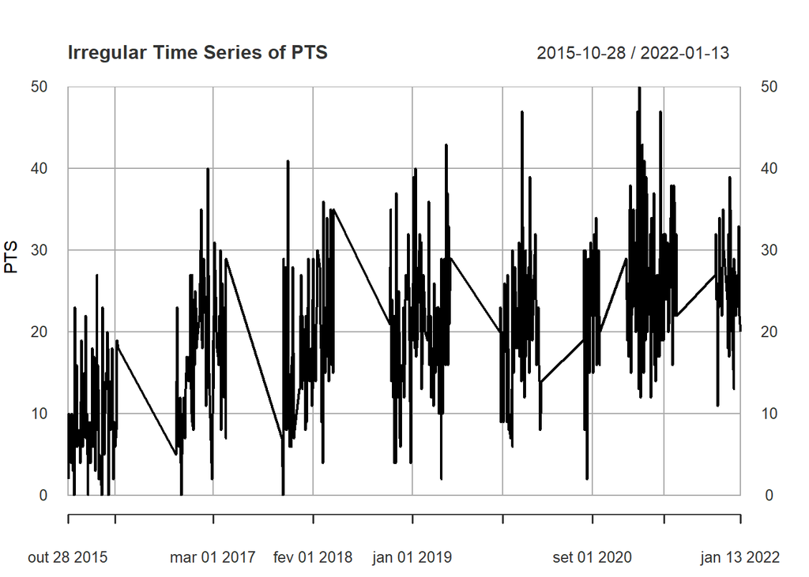

```r
# Converta a coluna 'date' para um formato de data apropriado
df_wtp$date <- as.POSIXct(df_wtp$date)

df_player <- df_wtp %>%
  filter(Name == player_name)

# Especifique a proporção de dados a serem usados para treinamento (por exemplo, 80%)
train_proportion <- 0.8

# Calcule o índice para dividir os dados
split_index <- floor(nrow(df_player) * train_proportion)

# Crie os conjuntos de treinamento e teste
train_data <- df_player[1:split_index, ]
test_data <- df_player[(split_index + 1):nrow(df_player), ]

# Converta os dados de treinamento para um objeto xts
train_time_series <- xts(train_data$PTS, order.by = train_data$date)
plot(train_time_series, main = "Irregular Time Series of PTS", ylab = "PTS", xlab = "Date")
```

```r
# Ajuste um modelo ARIMA aos dados de treinamento
arima_model <- auto.arima(train_time_series)

# Preveja os valores para os dados de teste
predicted_values <- forecast(arima_model, h = length(test_data$PTS))

# Converta os dados de teste para um objeto xts
test_time_series <- xts(test_data$PTS, order.by = test_data$date)

# Compare os valores previstos com os valores reais nos dados de teste
accuracy <- accuracy(predicted_values, test_time_series)
print(accuracy)
```

```
##                     ME     RMSE      MAE       MPE     MAPE      MASE
## Training set 0.4430918 7.849998 6.108766      -Inf      Inf 0.3128621
## Test set     1.6728090 8.837683 6.849658 -7.970373 31.53437 0.3508072
##                      ACF1
## Training set -0.004374811
## Test set               NA
```

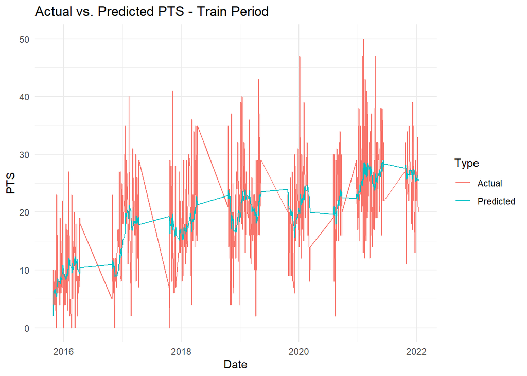

```r
# Converta os objetos xts em data frames para facilitar a plotagem
actual_train_data <- data.frame(Date = index(train_time_series), PTS = coredata(train_time_series))
predicted_train_data <- data.frame(Date = index(train_time_series), PTS = fitted(arima_model))

# Crie um data frame para plotar os valores reais e previstos
combined_train_data <- rbind(actual_train_data, predicted_train_data)
combined_train_data$Type <- c(rep("Actual", nrow(actual_train_data)), rep("Predicted", nrow(predicted_train_data)))

# Plot the actual and predicted values on the same graph for the training period
ggplot(combined_train_data, aes(x = Date, y = PTS, color = Type)) +
  geom_line() +
  labs(title = "Actual vs. Predicted PTS - Train Period",
       x = "Date",
       y = "PTS") +
  theme_minimal()
```

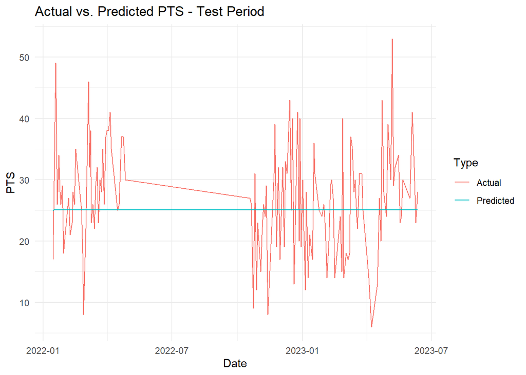

```r
# Converta os objetos xts em data frames para facilitar a plotagem
actual_test_data <- data.frame(Date = index(test_time_series), PTS = coredata(test_time_series))
predicted_test_data <- data.frame(Date = index(test_time_series), PTS = coredata(predicted_values$mean))

# Crie um data frame para plotar os valores reais e previstos
combined_test_data <- rbind(actual_test_data, predicted_test_data)
combined_test_data$Type <- c(rep("Actual", nrow(actual_test_data)), rep("Predicted", nrow(predicted_test_data)))

# Plot the actual and predicted values on the same graph for the test period
ggplot(combined_test_data, aes(x = Date, y = PTS, color = Type)) +
  geom_line() +
  labs(title = "Actual vs. Predicted PTS - Test Period",
       x = "Date",
       y = "PTS") +
  theme_minimal()
```

O primeiro modelo se mostra bastante ineficaz, como esperado, vou refazer adicionando as colunas do wtp e ver se tem um resultado melhor ou pior. Achei um comentário interessante no stackoverflow sobre esse tipo de problema: “I understand your problem. I currently work on a similar problem. (We have appointment schedules which are recurrent every week, but the schedules are often overruled if required, meaning irregular time series). I switched to machine learning, implemented a boosted regression tree, but there are many others. Time series are only appropriate if you think time aspects are responsible for the noise in data, but there are often so many different factors, like maybe the weather, or the product type, or interaction terms between two variables that might explain part of the noise.”

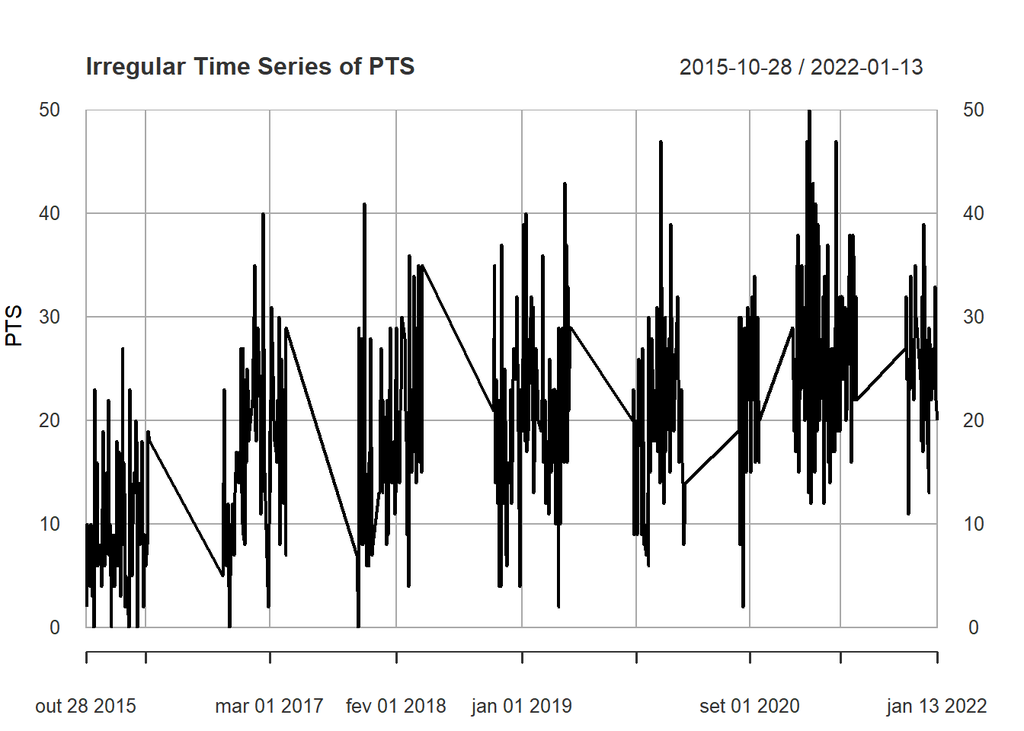

```r
# Converta a coluna 'date' para um formato de data apropriado
df_wtp$date <- as.POSIXct(df_wtp$date)

df_player <- df_wtp %>%
  filter(Name == player_name)

# Especifique a proporção de dados a serem usados para treinamento (por exemplo, 80%)
train_proportion <- 0.8

# Calcule o índice para dividir os dados
split_index <- floor(nrow(df_player) * train_proportion)

# Crie os conjuntos de treinamento e teste
train_data <- df_player[1:split_index, ]
test_data <- df_player[(split_index + 1):nrow(df_player), ]

# Converta os dados de treinamento para um objeto xts
train_time_series <- xts(train_data$PTS, order.by = train_data$date)
plot(train_time_series, main = "Irregular Time Series of PTS", ylab = "PTS", xlab = "Date")
```

```r
# Crie um data frame com as variáveis exógenas (todas as colunas iniciadas com "L5_" e "L10_", e "rest_days")
exog_vars <- as.matrix(train_data %>%
  select(starts_with("L5_"), starts_with("L10_"), "rest_days", "season"))

# Ajuste um modelo ARIMA aos dados de treinamento com variáveis exógenas
x_arima_model <- auto.arima(train_time_series, seasonal = TRUE, xreg = exog_vars)

# Preveja os valores para os dados de teste
exog_vars_test <- as.matrix(test_data %>%
  select(starts_with("L5_"), starts_with("L10_"), "rest_days", "season"))
predicted_values <- forecast(x_arima_model, xreg = exog_vars_test)

# Converta os dados de teste para um objeto xts
test_time_series <- xts(test_data$PTS, order.by = test_data$date)

# Compare os valores previstos com os valores reais nos dados de teste
accuracy <- accuracy(predicted_values, test_time_series)
print(accuracy)
```

```
##                         ME     RMSE      MAE       MPE     MAPE      MASE
## Training set -7.762532e-06 7.538896 5.976012      -Inf      Inf 0.3060631
## Test set     -1.147060e-01 9.085478 7.224980 -15.60377 34.81975 0.3700293
##                     ACF1
## Training set 0.006663904
## Test set              NA
```

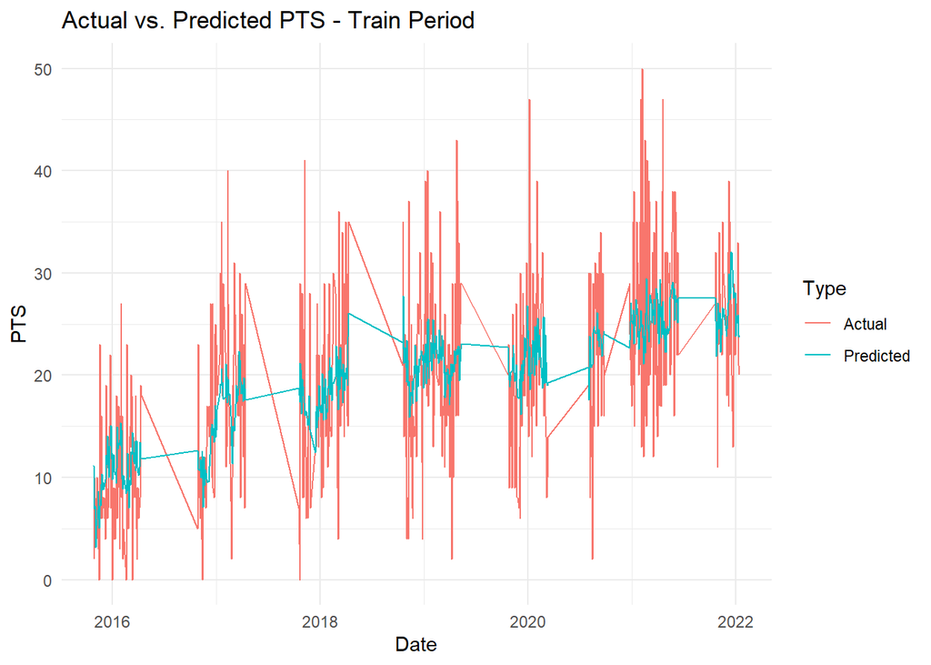

```r
# Converta os objetos xts em data frames para facilitar a plotagem
actual_train_data <- data.frame(Date = index(train_time_series), PTS = coredata(train_time_series))
predicted_train_data <- data.frame(Date = index(train_time_series), PTS = fitted(x_arima_model))

# Crie um data frame para plotar os valores reais e previstos
combined_train_data <- rbind(actual_train_data, predicted_train_data)
combined_train_data$Type <- c(rep("Actual", nrow(actual_train_data)), rep("Predicted", nrow(predicted_train_data)))

# Plot the actual and predicted values on the same graph for the training period
ggplot(combined_train_data, aes(x = Date, y = PTS, color = Type)) +
  geom_line() +
  labs(title = "Actual vs. Predicted PTS - Train Period",
       x = "Date",
       y = "PTS") +
  theme_minimal()
```

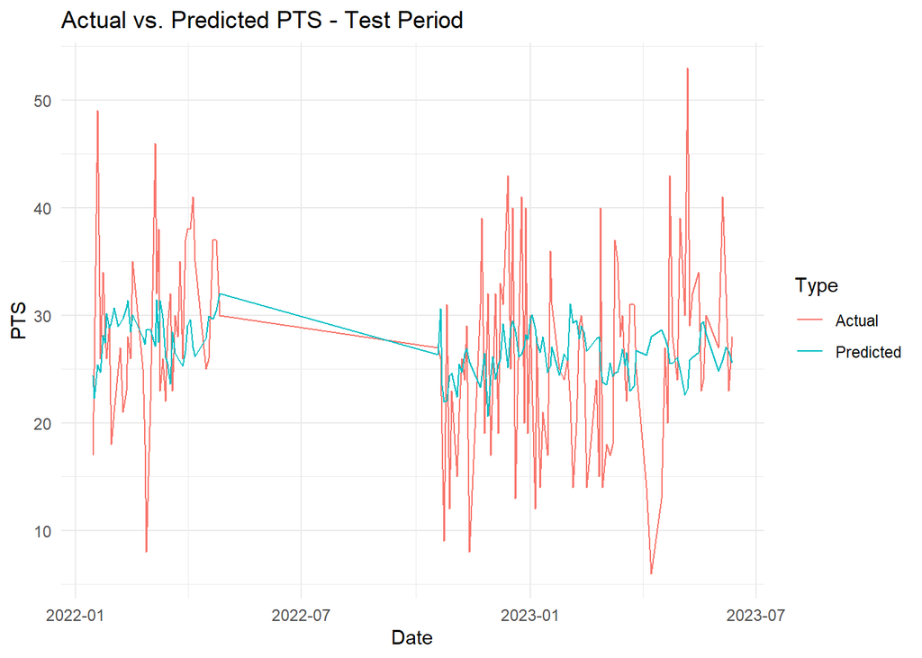

```r
# Converta os objetos xts em data frames para facilitar a plotagem
actual_test_data <- data.frame(Date = index(test_time_series), PTS = coredata(test_time_series))
predicted_test_data <- data.frame(Date = index(test_time_series), PTS = coredata(predicted_values$mean))

# Crie um data frame para plotar os valores reais e previstos
combined_test_data <- rbind(actual_test_data, predicted_test_data)
combined_test_data$Type <- c(rep("Actual", nrow(actual_test_data)), rep("Predicted", nrow(predicted_test_data)))

# Plot the actual and predicted values on the same graph for the test period
ggplot(combined_test_data, aes(x = Date, y = PTS, color = Type)) +
  geom_line() +
  labs(title = "Actual vs. Predicted PTS - Test Period",
       x = "Date",
       y = "PTS") +
  theme_minimal()
```

Considerações: O modelo criado não lida muito bem com as altas volatilidades da pontuação de um jogador, enquanto as pontuações tendem a variar muito, o modelo tende a variar pouco, as vezes na mesma direção, as vezes em direções opostas. Fiz o teste com jogadores diferentes e acontece o mesmo com todos eles.

```r
df_player <- df_wtp %>%
  filter(Name == player_name)

num_train_samples <- round(nrow(df_player) * .5)
num_val_samples <- round(nrow(df_player) * 0.25)
num_test_samples <- nrow(df_player) - num_train_samples - num_val_samples

train_df <- df_player[seq(num_train_samples), ]
val_df <- df_player[seq(from = nrow(train_df) + 1, length.out = num_val_samples),]
test_df <- df_player[seq(to = nrow(df_player), length.out = num_test_samples), ]

cat("num_train_samples:", nrow(train_df), "\n")
```

```
## num_train_samples: 332
```

```r
cat("num_val_samples:", nrow(val_df), "\n")
```

```
## num_val_samples: 166
```

```r
cat("num_test_samples:", nrow(test_df), "\n")
```

```
## num_test_samples: 166
```

```r
#Normalizing the data

input_data_colnames <- colnames(df_player %>%
  select(starts_with("L5_"), starts_with("L10_"), "rest_days", "ppm"))

# Calculate mean and standard deviation for each column in input_data_colnames
mean_values <- lapply(train_df[input_data_colnames], mean)
sd_values <- lapply(train_df[input_data_colnames], sd)

# Combine the mean and standard deviation values into a dataframe
normalization_values <- data.frame(
  Column = names(train_df[input_data_colnames]),
  Mean = unlist(mean_values),
  SD = unlist(sd_values)
)

# Print the normalization values
normalization_values
```

```
##                Column       Mean        SD
## L5_FG_opp   L5_FG_opp  4.7936747 2.6211530
## L5_FGA_opp L5_FGA_opp  9.2680723 4.7058945
## L5_3P_opp   L5_3P_opp  0.5421687 0.6143049
## L5_3PA_opp L5_3PA_opp  1.7018072 1.3980769
## L5_FT_opp   L5_FT_opp  2.1024096 1.7738603
## L5_FTA_opp L5_FTA_opp  2.6521084 2.0716534
## L5_ORB_opp L5_ORB_opp  2.1927711 1.1911845
## L5_DRB_opp L5_DRB_opp  5.5075301 2.8234726
## L5_TRB_opp L5_TRB_opp  7.9246988 3.7139475
## L5_AST_opp L5_AST_opp  3.7259036 2.5860170
## L5_STL_opp L5_STL_opp  0.8057229 0.7480471
## L5_BLK_opp L5_BLK_opp  0.4638554 0.5687381
## L5_TOV_opp L5_TOV_opp  1.6972892 1.1194889
## L5_PF_opp   L5_PF_opp  2.4457831 1.2443517
## L5_BPM_opp L5_BPM_opp  4.9561747 6.1079352
## L5_PTS_opp L5_PTS_opp 12.3795181 6.6777759
## L5_ppm_opp L5_ppm_opp  0.4677010 0.1980927
## L10_FG         L10_FG  6.0632530 2.2776808
## L10_FGA       L10_FGA 11.8072289 4.0856253
## L10_3P         L10_3P  0.6807229 0.5987314
## L10_3PA       L10_3PA  2.3539157 1.3267694
## L10_FT         L10_FT  2.5963855 1.4400567
## L10_FTA       L10_FTA  3.1385542 1.5620369
## L10_ORB       L10_ORB  2.5542169 0.7870249
## L10_DRB       L10_DRB  6.8554217 2.3026717
## L10_TRB       L10_TRB  9.6716867 2.6649305
## L10_AST       L10_AST  4.9728916 2.4076640
## L10_STL       L10_STL  0.9021084 0.5158178
## L10_BLK       L10_BLK  0.4638554 0.4382272
## L10_TOV       L10_TOV  2.1250000 0.9328877
## L10_PF         L10_PF  2.7966867 0.6630661
## L10_BPM       L10_BPM  6.4403614 3.9863662
## L10_PTS       L10_PTS 16.0572289 5.6065382
## L10_ppm       L10_ppm  0.5590079 0.1133517
## rest_days   rest_days  2.2228916 1.3636476
## ppm               ppm  0.5572753 0.2289835
```

```r
normalize_input_data <- function(df) {
  normalize <- function(x, center, scale) {
    (x - center) / scale
  }

  for (col_nm in input_data_colnames) {
    col_nv <- normalization_values[normalization_values$Column == col_nm,]
    df[[col_nm]] <- normalize(df[[col_nm]], col_nv$Mean, col_nv$SD)
  }

  return(df)
}

# Apply the normalization function to your dataframe (e.g., train_df)
normalized_train_df <- normalize_input_data(train_df)
```

Dados do exemplo: 1 leitura a cada hora. sequence_length = 5 dias. Delay = 6 dias -1 hora sampling_rate <- 6 sequence_length <- 120 delay <- sampling_rate * (sequence_length + 24 - 1) batch_size <- 256

```r
sampling_rate <- 6
sequence_length <- 10
delay <- sampling_rate * (sequence_length  - 1)
batch_size <- 128

# Define the function to prepare inputs and targets
df_to_inputs_and_targets <- function(df, delay) {
  inputs <- df[input_data_colnames] %>%
    normalize_input_data() %>%
    as.matrix()

  targets <- as.array(df$PTS)

  list(
    head(inputs, -delay),
    tail(targets, -delay)
  )
}

# Define the function to create a time series dataset
make_dataset <- function(df) {
  inputs_and_targets <- df_to_inputs_and_targets(df, delay)
  inputs <- inputs_and_targets[[1]]
  targets <- inputs_and_targets[[2]]

  timeseries_dataset_from_array(
    inputs, targets,
    sampling_rate = sampling_rate,
    sequence_length = sequence_length,
    shuffle = TRUE,
    batch_size = batch_size
  )
}

train_dataset <- make_dataset(train_df)
val_dataset <- make_dataset(val_df)
test_dataset <- make_dataset(test_df)
```

Seguindo os passos do livro “Deep Learning with R”, primeiro fazemos um modelo simplista para ter como parametro de métricas.

```r
library(tfdatasets)

options(tensorflow.extract.warn_negatives_pythonic = FALSE)

#Essas funções abaixo não estão vindo embutidas no tfdatasets por algum motivo e são necessárias para rodar o código abaixo.

as_py_function <- function(x) {
  if (inherits(x, "python.builtin.function")) {
    x
  } else {
    rlang::as_function(x)
  }
}

as_integer_tensor <- function(x, dtype = tf$int64) {

  # recurse over lists
  if (is.list(x) || (is.numeric(x) && length(x) > 1))
    lapply(x, function(elem) as_integer_tensor(elem, dtype))
  else if (is.null(x))
    x
  else if (is_tensor(x))
    tf$cast(x, dtype = dtype)
  else
    tf$constant(as.integer(x), dtype = dtype)
}




###
c(samples, targets) %<-% iter_next(as_iterator(train_dataset))
cat("samples shape: ", format(samples$shape), "\n",
"targets shape: ", format(targets$shape), "\n", sep = "")
```

```
## samples shape: (128, 10, 36)
## targets shape: (128)
```

```r
#Training and evaluating a densely connected model

ncol_input_data <- length(input_data_colnames)
inputs <- layer_input(shape = c(sequence_length, ncol_input_data))
outputs <- inputs %>%
            layer_flatten() %>%
            layer_dense(16, activation = "relu") %>%
            layer_dense(1)

model <- keras_model(inputs, outputs)

early_stopping <- callback_early_stopping(
  monitor = "val_loss",  # Monitor validation loss
  patience = 10,         # Number of epochs with no improvement before stopping
  verbose = 1            # Show messages about early stopping
)

model %>%
    compile(
      optimizer = "rmsprop",
      loss = "mse",
      metrics = list("mae", "mse")
    )

history <- model %>%
            fit(train_dataset,
            epochs = 10,
            validation_data = val_dataset,
            callbacks = list(early_stopping))
```

```
## 2/2 - 1s - loss: 395.0462 - mae: 17.9043 - mse: 395.0462 - val_loss: 699.5626 - val_mae: 24.8269 - val_mse: 699.5626 - 564ms/epoch - 282ms/step
## 2/2 - 0s - loss: 371.0621 - mae: 17.1701 - mse: 371.0621 - val_loss: 681.6449 - val_mae: 24.4678 - val_mse: 681.6449 - 65ms/epoch - 32ms/step
## 2/2 - 0s - loss: 356.3759 - mae: 16.6883 - mse: 356.3759 - val_loss: 660.2020 - val_mae: 24.0273 - val_mse: 660.2020 - 51ms/epoch - 25ms/step
## 2/2 - 0s - loss: 344.3021 - mae: 16.3140 - mse: 344.3021 - val_loss: 648.2148 - val_mae: 23.7828 - val_mse: 648.2148 - 72ms/epoch - 36ms/step
## 2/2 - 0s - loss: 334.2370 - mae: 15.9811 - mse: 334.2370 - val_loss: 637.4590 - val_mae: 23.5602 - val_mse: 637.4590 - 61ms/epoch - 31ms/step
## 2/2 - 0s - loss: 325.1808 - mae: 15.6800 - mse: 325.1808 - val_loss: 623.7408 - val_mae: 23.2735 - val_mse: 623.7408 - 58ms/epoch - 29ms/step
## 2/2 - 0s - loss: 317.0693 - mae: 15.4186 - mse: 317.0693 - val_loss: 612.0348 - val_mae: 23.0308 - val_mse: 612.0348 - 54ms/epoch - 27ms/step
## 2/2 - 0s - loss: 309.3809 - mae: 15.1530 - mse: 309.3809 - val_loss: 598.4281 - val_mae: 22.7415 - val_mse: 598.4281 - 68ms/epoch - 34ms/step
## 2/2 - 0s - loss: 302.1548 - mae: 14.9107 - mse: 302.1548 - val_loss: 583.1252 - val_mae: 22.4104 - val_mse: 583.1252 - 59ms/epoch - 29ms/step
## 2/2 - 0s - loss: 295.0418 - mae: 14.6750 - mse: 295.0418 - val_loss: 570.5148 - val_mae: 22.1330 - val_mse: 570.5148 - 54ms/epoch - 27ms/step
```

```r
model_weights_file <- "simple_model.keras"

save_model_weights_hdf5(model, model_weights_file)

eval_model <- evaluate(model, test_dataset)
```

```
## 1/1 - 0s - loss: 579.0920 - mae: 22.3267 - mse: 579.0920 - 39ms/epoch - 39ms/step
```

```r
mae <- eval_model[["mae"]]
mse <- eval_model[["mse"]]
rmse <- sqrt(mse)  # Calculate RMSE from MSE

sprintf("Test MAE: %.2f", mae)
```

```
## [1] "Test MAE: 22.33"
```

```r
sprintf("Test MSE: %.2f", mse)
```

```
## [1] "Test MSE: 579.09"
```

```r
sprintf("Test RMSE: %.2f", rmse)  # Print RMSE
```

```
## [1] "Test RMSE: 24.06"
```

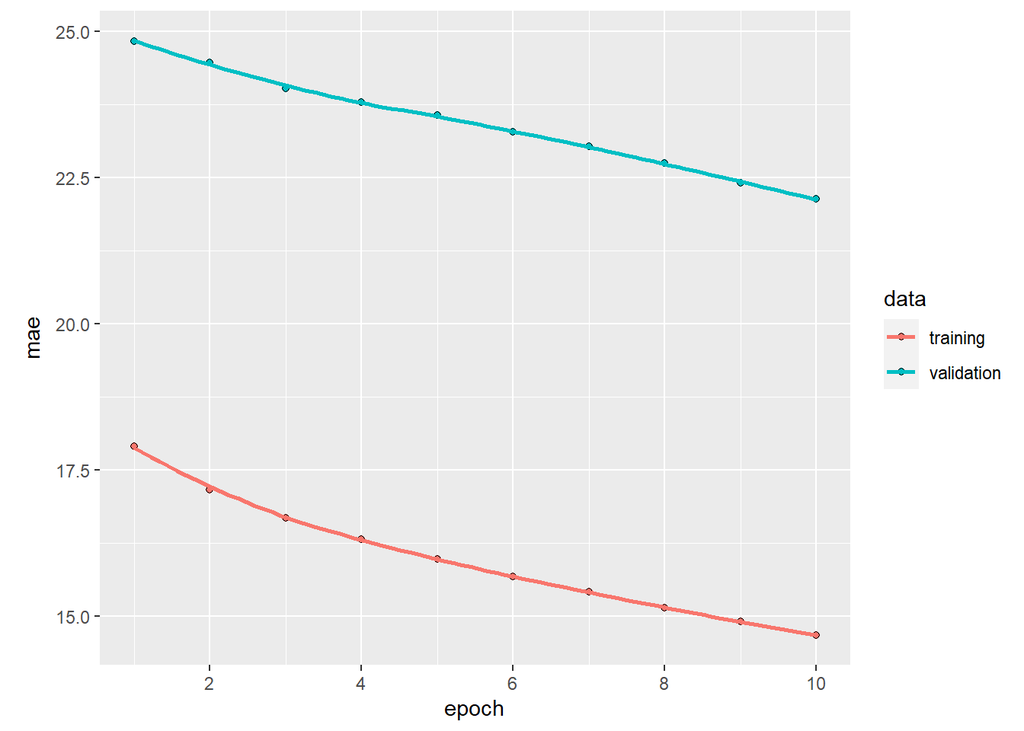

```r
#Plotting results
plot(history, metrics = "mae")
```

Estou com problemas na arquitetura de rede neural convolucional abaixo, ValueError: One of the dimensions in the output is <= 0 due to downsampling in conv1d_23. Consider increasing the input size. Received input shape [None, 10, 37] which would produce output shape with a zero or negative value in a dimension.

```r
inputs <- layer_input(shape = c(sequence_length, ncol_input_data))

outputs <- inputs %>%
          layer_conv_1d(8, 12, activation = "relu") %>%
          layer_max_pooling_1d(2) %>%
          layer_conv_1d(8, 6, activation = "relu") %>%
          layer_max_pooling_1d(2) %>%
          layer_conv_1d(8, 3, activation = "relu") %>%
          layer_global_average_pooling_1d() %>%
          layer_dense(1)

model <- keras_model(inputs, outputs)

early_stopping <- callback_early_stopping(
  monitor = "val_loss",  # Monitor validation loss
  patience = 10,         # Number of epochs with no improvement before stopping
  verbose = 1            # Show messages about early stopping
)

model %>%
    compile(
      optimizer = "rmsprop",
      loss = "mse",
      metrics = list("mae", "mse")
    )

history <- model %>% fit(
      train_dataset,
      epochs = 50,
      validation_data = val_dataset,
      callbacks = list(early_stopping)
      )

model_weights_file <- "conv_model.keras"

save_model_weights_hdf5(model, model_weights_file)

eval_model <- evaluate(model, test_dataset)
mae <- eval_model[["mae"]]
mse <- eval_model[["mse"]]
rmse <- sqrt(mse)  # Calculate RMSE from MSE

sprintf("Test MAE: %.2f", mae)
sprintf("Test MSE: %.2f", mse)
sprintf("Test RMSE: %.2f", rmse)  # Print RMSE

plot(history)
```

```r
inputs <- layer_input(shape = c(sequence_length, ncol_input_data))
outputs <- inputs %>%
          layer_lstm(16) %>%
          layer_dense(1)
model <- keras_model(inputs, outputs)

early_stopping <- callback_early_stopping(
  monitor = "val_loss",  # Monitor validation loss
  patience = 10,         # Number of epochs with no improvement before stopping
  verbose = 1            # Show messages about early stopping
)

model %>%
    compile(
      optimizer = "rmsprop",
      loss = "mse",
      metrics = list("mae", "mse")
    )

history <- model %>% fit(
        train_dataset,
        epochs = 50,
        validation_data = val_dataset,
        callbacks = list(early_stopping)
        )
```

```
## 2/2 - 2s - loss: 373.2746 - mae: 17.3108 - mse: 373.2746 - val_loss: 675.3986 - val_mae: 24.3303 - val_mse: 675.3986 - 2s/epoch - 1s/step
## 2/2 - 0s - loss: 369.0458 - mae: 17.1973 - mse: 369.0458 - val_loss: 667.9725 - val_mae: 24.1818 - val_mse: 667.9725 - 57ms/epoch - 29ms/step
## 2/2 - 0s - loss: 365.9076 - mae: 17.1124 - mse: 365.9076 - val_loss: 662.1241 - val_mae: 24.0642 - val_mse: 662.1241 - 58ms/epoch - 29ms/step
## 2/2 - 0s - loss: 363.1577 - mae: 17.0351 - mse: 363.1577 - val_loss: 657.0958 - val_mae: 23.9625 - val_mse: 657.0958 - 61ms/epoch - 31ms/step
## 2/2 - 0s - loss: 360.6105 - mae: 16.9644 - mse: 360.6105 - val_loss: 652.3920 - val_mae: 23.8666 - val_mse: 652.3920 - 61ms/epoch - 30ms/step
## 2/2 - 0s - loss: 358.1234 - mae: 16.8942 - mse: 358.1234 - val_loss: 647.8225 - val_mae: 23.7730 - val_mse: 647.8225 - 59ms/epoch - 30ms/step
## 2/2 - 0s - loss: 355.6934 - mae: 16.8265 - mse: 355.6934 - val_loss: 643.1790 - val_mae: 23.6771 - val_mse: 643.1790 - 57ms/epoch - 29ms/step
## 2/2 - 0s - loss: 353.2759 - mae: 16.7584 - mse: 353.2759 - val_loss: 638.9654 - val_mae: 23.5896 - val_mse: 638.9654 - 56ms/epoch - 28ms/step
## 2/2 - 0s - loss: 350.9116 - mae: 16.6906 - mse: 350.9116 - val_loss: 634.6987 - val_mae: 23.5005 - val_mse: 634.6987 - 56ms/epoch - 28ms/step
## 2/2 - 0s - loss: 348.5565 - mae: 16.6238 - mse: 348.5565 - val_loss: 630.4636 - val_mae: 23.4114 - val_mse: 630.4636 - 59ms/epoch - 29ms/step
## 2/2 - 0s - loss: 346.2019 - mae: 16.5579 - mse: 346.2019 - val_loss: 625.9620 - val_mae: 23.3158 - val_mse: 625.9620 - 60ms/epoch - 30ms/step
## 2/2 - 0s - loss: 343.8267 - mae: 16.4901 - mse: 343.8267 - val_loss: 621.8889 - val_mae: 23.2288 - val_mse: 621.8889 - 58ms/epoch - 29ms/step
## 2/2 - 0s - loss: 341.4885 - mae: 16.4231 - mse: 341.4885 - val_loss: 617.5854 - val_mae: 23.1363 - val_mse: 617.5854 - 58ms/epoch - 29ms/step
## 2/2 - 0s - loss: 339.0852 - mae: 16.3562 - mse: 339.0852 - val_loss: 613.7173 - val_mae: 23.0528 - val_mse: 613.7173 - 58ms/epoch - 29ms/step
## 2/2 - 0s - loss: 336.6777 - mae: 16.2876 - mse: 336.6777 - val_loss: 610.1409 - val_mae: 22.9752 - val_mse: 610.1409 - 59ms/epoch - 29ms/step
## 2/2 - 0s - loss: 334.2887 - mae: 16.2184 - mse: 334.2887 - val_loss: 606.7700 - val_mae: 22.9017 - val_mse: 606.7700 - 62ms/epoch - 31ms/step
## 2/2 - 0s - loss: 331.9114 - mae: 16.1500 - mse: 331.9114 - val_loss: 603.2370 - val_mae: 22.8243 - val_mse: 603.2370 - 61ms/epoch - 31ms/step
## 2/2 - 0s - loss: 329.4997 - mae: 16.0806 - mse: 329.4997 - val_loss: 600.3728 - val_mae: 22.7615 - val_mse: 600.3728 - 62ms/epoch - 31ms/step
## 2/2 - 0s - loss: 327.0829 - mae: 16.0108 - mse: 327.0829 - val_loss: 597.6224 - val_mae: 22.7009 - val_mse: 597.6224 - 60ms/epoch - 30ms/step
## 2/2 - 0s - loss: 324.6558 - mae: 15.9408 - mse: 324.6558 - val_loss: 594.7527 - val_mae: 22.6374 - val_mse: 594.7527 - 62ms/epoch - 31ms/step
## 2/2 - 0s - loss: 322.2238 - mae: 15.8693 - mse: 322.2238 - val_loss: 592.4538 - val_mae: 22.5864 - val_mse: 592.4538 - 68ms/epoch - 34ms/step
## 2/2 - 0s - loss: 319.7749 - mae: 15.7975 - mse: 319.7749 - val_loss: 590.3522 - val_mae: 22.5398 - val_mse: 590.3522 - 101ms/epoch - 51ms/step
## 2/2 - 0s - loss: 317.3190 - mae: 15.7248 - mse: 317.3190 - val_loss: 588.2206 - val_mae: 22.4924 - val_mse: 588.2206 - 88ms/epoch - 44ms/step
## 2/2 - 0s - loss: 314.8431 - mae: 15.6517 - mse: 314.8431 - val_loss: 586.0992 - val_mae: 22.4450 - val_mse: 586.0992 - 68ms/epoch - 34ms/step
## 2/2 - 0s - loss: 312.3565 - mae: 15.5777 - mse: 312.3565 - val_loss: 584.2802 - val_mae: 22.4044 - val_mse: 584.2802 - 61ms/epoch - 31ms/step
## 2/2 - 0s - loss: 309.8690 - mae: 15.5038 - mse: 309.8690 - val_loss: 582.7147 - val_mae: 22.3696 - val_mse: 582.7147 - 61ms/epoch - 30ms/step
## 2/2 - 0s - loss: 307.3732 - mae: 15.4282 - mse: 307.3732 - val_loss: 581.6451 - val_mae: 22.3462 - val_mse: 581.6451 - 62ms/epoch - 31ms/step
## 2/2 - 0s - loss: 304.9020 - mae: 15.3549 - mse: 304.9020 - val_loss: 580.3491 - val_mae: 22.3175 - val_mse: 580.3491 - 66ms/epoch - 33ms/step
## 2/2 - 0s - loss: 302.4543 - mae: 15.2799 - mse: 302.4543 - val_loss: 579.5304 - val_mae: 22.2998 - val_mse: 579.5304 - 64ms/epoch - 32ms/step
## 2/2 - 0s - loss: 299.9859 - mae: 15.2062 - mse: 299.9859 - val_loss: 578.6948 - val_mae: 22.2818 - val_mse: 578.6948 - 62ms/epoch - 31ms/step
## 2/2 - 0s - loss: 297.5212 - mae: 15.1308 - mse: 297.5212 - val_loss: 577.3485 - val_mae: 22.2517 - val_mse: 577.3485 - 70ms/epoch - 35ms/step
```

[output cut: 16 more lines]

```r
model_weights_file <- "lstm_model.keras"

save_model_weights_hdf5(model, model_weights_file)

eval_model <- evaluate(model, test_dataset)
```

```
## 1/1 - 0s - loss: 771.1879 - mae: 26.3436 - mse: 771.1879 - 35ms/epoch - 35ms/step
```

```r
mae <- eval_model[["mae"]]
mse <- eval_model[["mse"]]
rmse <- sqrt(mse)

sprintf("Test MAE: %.2f", mae)
```

```
## [1] "Test MAE: 26.34"
```

```r
sprintf("Test MSE: %.2f", mse)
```

```
## [1] "Test MSE: 771.19"
```

```r
sprintf("Test RMSE: %.2f", rmse)  # Print RMSE
```

```
## [1] "Test RMSE: 27.77"
```

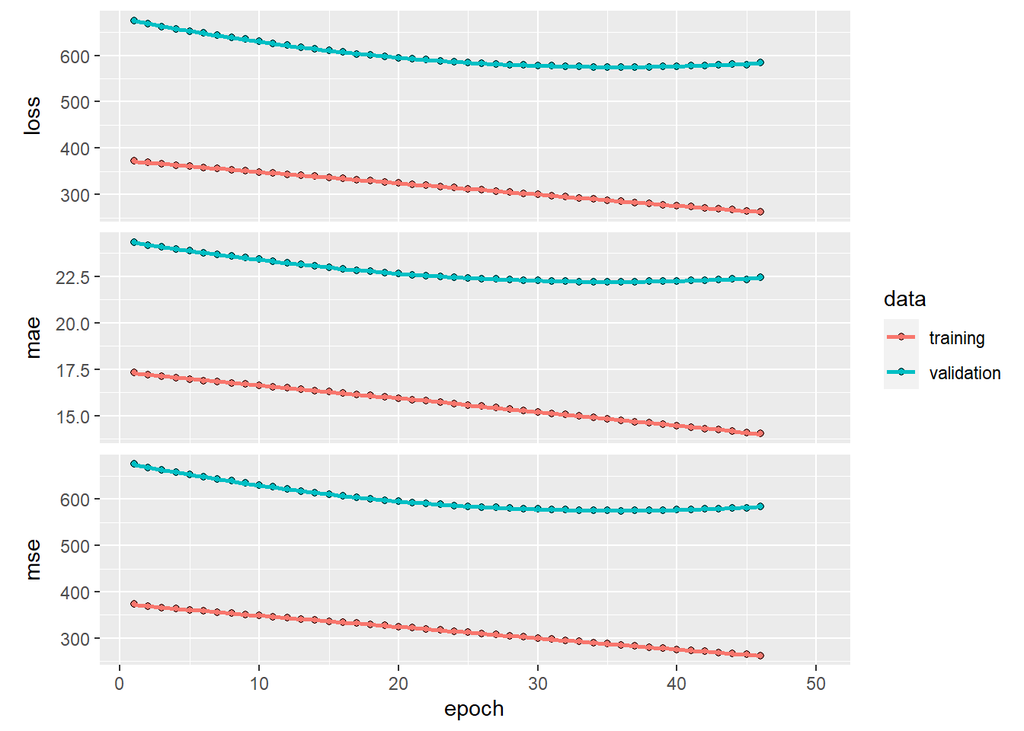

```r
plot(history)
```

```r
#Listing 10.21 Training and evaluating a dropout-regularized LSTM

inputs <- layer_input(shape = c(sequence_length, ncol_input_data))
outputs <- inputs %>%
        layer_lstm(32, recurrent_dropout = 0.25) %>%
        layer_dropout(0.5) %>%
        layer_dense(1)

model <- keras_model(inputs, outputs)

early_stopping <- callback_early_stopping(
  monitor = "val_loss",  # Monitor validation loss
  patience = 10,         # Number of epochs with no improvement before stopping
  verbose = 1            # Show messages about early stopping
)

model %>%
    compile(
      optimizer = "rmsprop",
      loss = "mse",
      metrics = list("mae", "mse")
    )

history <- model %>% fit(
    train_dataset,
    epochs = 50,
    validation_data = val_dataset,
    callbacks = list(early_stopping)
)
```

```
## 2/2 - 2s - loss: 380.2951 - mae: 17.4788 - mse: 380.2951 - val_loss: 673.3542 - val_mae: 24.2678 - val_mse: 673.3542 - 2s/epoch - 1s/step
## 2/2 - 0s - loss: 371.0715 - mae: 17.2446 - mse: 371.0715 - val_loss: 660.0781 - val_mae: 23.9963 - val_mse: 660.0781 - 61ms/epoch - 31ms/step
## 2/2 - 0s - loss: 366.3404 - mae: 17.0935 - mse: 366.3404 - val_loss: 646.3097 - val_mae: 23.7099 - val_mse: 646.3097 - 60ms/epoch - 30ms/step
## 2/2 - 0s - loss: 359.2618 - mae: 16.8900 - mse: 359.2618 - val_loss: 633.0040 - val_mae: 23.4292 - val_mse: 633.0040 - 57ms/epoch - 29ms/step
## 2/2 - 0s - loss: 354.3676 - mae: 16.7767 - mse: 354.3676 - val_loss: 620.4186 - val_mae: 23.1633 - val_mse: 620.4186 - 59ms/epoch - 30ms/step
## 2/2 - 0s - loss: 349.1666 - mae: 16.6016 - mse: 349.1666 - val_loss: 608.3891 - val_mae: 22.9053 - val_mse: 608.3891 - 57ms/epoch - 29ms/step
## 2/2 - 0s - loss: 341.0033 - mae: 16.3910 - mse: 341.0033 - val_loss: 595.0453 - val_mae: 22.6149 - val_mse: 595.0453 - 58ms/epoch - 29ms/step
## 2/2 - 0s - loss: 333.9967 - mae: 16.2234 - mse: 333.9967 - val_loss: 583.6108 - val_mae: 22.3636 - val_mse: 583.6108 - 59ms/epoch - 29ms/step
## 2/2 - 0s - loss: 328.4026 - mae: 16.0148 - mse: 328.4026 - val_loss: 572.3686 - val_mae: 22.1181 - val_mse: 572.3686 - 61ms/epoch - 30ms/step
## 2/2 - 0s - loss: 320.9471 - mae: 15.8170 - mse: 320.9471 - val_loss: 559.9791 - val_mae: 21.8469 - val_mse: 559.9791 - 58ms/epoch - 29ms/step
## 2/2 - 0s - loss: 314.3166 - mae: 15.6250 - mse: 314.3166 - val_loss: 546.9305 - val_mae: 21.5573 - val_mse: 546.9305 - 59ms/epoch - 29ms/step
## 2/2 - 0s - loss: 306.1230 - mae: 15.3734 - mse: 306.1230 - val_loss: 533.3640 - val_mae: 21.2528 - val_mse: 533.3640 - 60ms/epoch - 30ms/step
## 2/2 - 0s - loss: 299.6088 - mae: 15.1696 - mse: 299.6088 - val_loss: 523.0276 - val_mae: 21.0167 - val_mse: 523.0276 - 59ms/epoch - 30ms/step
## 2/2 - 0s - loss: 293.8679 - mae: 14.9845 - mse: 293.8679 - val_loss: 512.0563 - val_mae: 20.7634 - val_mse: 512.0563 - 59ms/epoch - 30ms/step
## 2/2 - 0s - loss: 284.0390 - mae: 14.6841 - mse: 284.0390 - val_loss: 501.1113 - val_mae: 20.5068 - val_mse: 501.1113 - 61ms/epoch - 31ms/step
## 2/2 - 0s - loss: 275.4681 - mae: 14.4402 - mse: 275.4681 - val_loss: 488.9157 - val_mae: 20.2168 - val_mse: 488.9157 - 65ms/epoch - 32ms/step
## 2/2 - 0s - loss: 267.2577 - mae: 14.1880 - mse: 267.2577 - val_loss: 477.2276 - val_mae: 19.9343 - val_mse: 477.2276 - 68ms/epoch - 34ms/step
## 2/2 - 0s - loss: 258.6253 - mae: 13.9272 - mse: 258.6253 - val_loss: 467.7574 - val_mae: 19.7002 - val_mse: 467.7574 - 62ms/epoch - 31ms/step
## 2/2 - 0s - loss: 250.2034 - mae: 13.6591 - mse: 250.2034 - val_loss: 457.1801 - val_mae: 19.4354 - val_mse: 457.1801 - 60ms/epoch - 30ms/step
## 2/2 - 0s - loss: 242.5382 - mae: 13.3563 - mse: 242.5382 - val_loss: 447.6145 - val_mae: 19.1922 - val_mse: 447.6145 - 90ms/epoch - 45ms/step
## 2/2 - 0s - loss: 236.3582 - mae: 13.2147 - mse: 236.3582 - val_loss: 439.9579 - val_mae: 18.9951 - val_mse: 439.9579 - 64ms/epoch - 32ms/step
## 2/2 - 0s - loss: 235.4743 - mae: 13.1626 - mse: 235.4743 - val_loss: 433.4458 - val_mae: 18.8260 - val_mse: 433.4458 - 64ms/epoch - 32ms/step
## 2/2 - 0s - loss: 222.8665 - mae: 12.6734 - mse: 222.8665 - val_loss: 426.2929 - val_mae: 18.6389 - val_mse: 426.2929 - 70ms/epoch - 35ms/step
## 2/2 - 0s - loss: 218.4109 - mae: 12.6015 - mse: 218.4109 - val_loss: 419.1476 - val_mae: 18.4495 - val_mse: 419.1476 - 61ms/epoch - 31ms/step
## 2/2 - 0s - loss: 211.0174 - mae: 12.3727 - mse: 211.0174 - val_loss: 413.5440 - val_mae: 18.3006 - val_mse: 413.5440 - 64ms/epoch - 32ms/step
## 2/2 - 0s - loss: 206.8935 - mae: 12.2220 - mse: 206.8935 - val_loss: 408.2229 - val_mae: 18.1581 - val_mse: 408.2229 - 61ms/epoch - 30ms/step
## 2/2 - 0s - loss: 206.0149 - mae: 12.1723 - mse: 206.0149 - val_loss: 404.5106 - val_mae: 18.0581 - val_mse: 404.5106 - 59ms/epoch - 29ms/step
## 2/2 - 0s - loss: 201.9229 - mae: 11.9927 - mse: 201.9229 - val_loss: 401.5275 - val_mae: 17.9778 - val_mse: 401.5275 - 68ms/epoch - 34ms/step
## 2/2 - 0s - loss: 195.5498 - mae: 11.7589 - mse: 195.5498 - val_loss: 399.4665 - val_mae: 17.9224 - val_mse: 399.4665 - 60ms/epoch - 30ms/step
## 2/2 - 0s - loss: 191.5817 - mae: 11.5960 - mse: 191.5817 - val_loss: 394.8813 - val_mae: 17.7984 - val_mse: 394.8813 - 63ms/epoch - 32ms/step
## 2/2 - 0s - loss: 187.4104 - mae: 11.4235 - mse: 187.4104 - val_loss: 394.7044 - val_mae: 17.7951 - val_mse: 394.7044 - 63ms/epoch - 31ms/step
## 2/2 - 0s - loss: 181.1617 - mae: 11.2917 - mse: 181.1617 - val_loss: 395.9634 - val_mae: 17.8312 - val_mse: 395.9634 - 65ms/epoch - 32ms/step
## 2/2 - 0s - loss: 182.8315 - mae: 11.2015 - mse: 182.8315 - val_loss: 397.2406 - val_mae: 17.8689 - val_mse: 397.2406 - 62ms/epoch - 31ms/step
## 2/2 - 0s - loss: 174.4272 - mae: 10.9295 - mse: 174.4272 - val_loss: 398.0863 - val_mae: 17.8956 - val_mse: 398.0863 - 68ms/epoch - 34ms/step
## 2/2 - 0s - loss: 172.6968 - mae: 10.8449 - mse: 172.6968 - val_loss: 406.5126 - val_mae: 18.1268 - val_mse: 406.5126 - 65ms/epoch - 33ms/step
## 2/2 - 0s - loss: 173.5817 - mae: 10.7922 - mse: 173.5817 - val_loss: 415.4811 - val_mae: 18.3690 - val_mse: 415.4811 - 66ms/epoch - 33ms/step
## 2/2 - 0s - loss: 169.6790 - mae: 10.7102 - mse: 169.6790 - val_loss: 431.4761 - val_mae: 18.7853 - val_mse: 431.4761 - 63ms/epoch - 31ms/step
## 2/2 - 0s - loss: 162.2923 - mae: 10.4256 - mse: 162.2923 - val_loss: 454.5829 - val_mae: 19.3667 - val_mse: 454.5829 - 62ms/epoch - 31ms/step
## 2/2 - 0s - loss: 161.0710 - mae: 10.3449 - mse: 161.0710 - val_loss: 469.2355 - val_mae: 19.7246 - val_mse: 469.2355 - 68ms/epoch - 34ms/step
## 2/2 - 0s - loss: 157.5394 - mae: 10.1575 - mse: 157.5394 - val_loss: 494.5623 - val_mae: 20.3369 - val_mse: 494.5623 - 64ms/epoch - 32ms/step
## 2/2 - 0s - loss: 156.4076 - mae: 10.0295 - mse: 156.4076 - val_loss: 519.7710 - val_mae: 20.9544 - val_mse: 519.7710 - 68ms/epoch - 34ms/step
## Epoch 41: early stopping
```

```r
model_weights_file <- "lstm_dropout_model.keras"

save_model_weights_hdf5(model, model_weights_file)

eval_model <- evaluate(model, test_dataset)
```

```
## 1/1 - 0s - loss: 627.3065 - mae: 23.4489 - mse: 627.3065 - 25ms/epoch - 25ms/step
```

```r
mae <- eval_model[["mae"]]
mse <- eval_model[["mse"]]
rmse <- sqrt(mse)

sprintf("Test MAE: %.2f", mae)
```

```
## [1] "Test MAE: 23.45"
```

```r
sprintf("Test RMSE: %.2f", rmse)
```

```
## [1] "Test RMSE: 25.05"
```

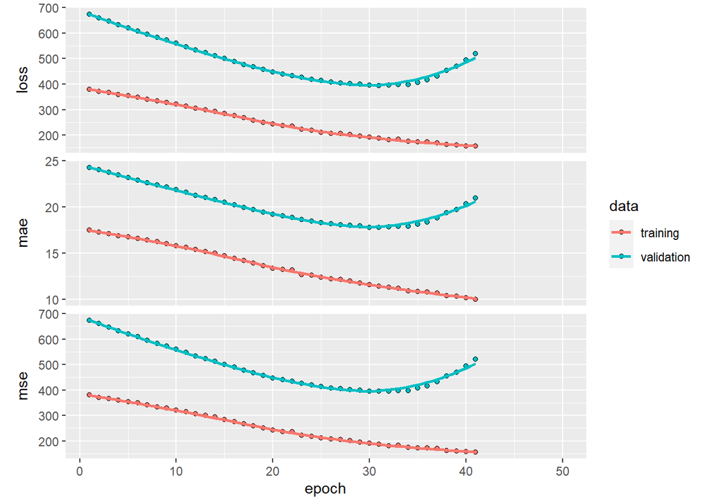

```r
plot(history)
```

```r
#Listing 10.22 Training and evaluating a dropout-regularized, stacked GRU model

inputs <- layer_input(shape = c(sequence_length, ncol_input_data))
outputs <- inputs %>%
          layer_gru(32, recurrent_dropout = 0.5, return_sequences = TRUE) %>%
          layer_gru(32, recurrent_dropout = 0.5) %>%
          layer_dropout(0.5) %>%
          layer_dense(1)

early_stopping <- callback_early_stopping(
  monitor = "val_loss",  # Monitor validation loss
  patience = 10,         # Number of epochs with no improvement before stopping
  verbose = 1            # Show messages about early stopping
)

model %>%
    compile(
      optimizer = "rmsprop",
      loss = "mse",
      metrics = list("mae", "mse")
    )

history <- model %>% fit(
    train_dataset,
    epochs = 50,
    validation_data = val_dataset,
    callbacks = list(early_stopping)
)
```

```
## 2/2 - 3s - loss: 155.2746 - mae: 9.9333 - mse: 155.2746 - val_loss: 571.7568 - val_mae: 22.1650 - val_mse: 571.7568 - 3s/epoch - 1s/step
## 2/2 - 0s - loss: 140.8978 - mae: 9.4916 - mse: 140.8978 - val_loss: 544.4551 - val_mae: 21.5176 - val_mse: 544.4551 - 86ms/epoch - 43ms/step
## 2/2 - 0s - loss: 145.6056 - mae: 9.5935 - mse: 145.6056 - val_loss: 616.2878 - val_mae: 23.1357 - val_mse: 616.2878 - 66ms/epoch - 33ms/step
## 2/2 - 0s - loss: 147.0466 - mae: 9.6512 - mse: 147.0466 - val_loss: 594.3422 - val_mae: 22.6374 - val_mse: 594.3422 - 85ms/epoch - 43ms/step
## 2/2 - 0s - loss: 134.9886 - mae: 9.1175 - mse: 134.9886 - val_loss: 655.9087 - val_mae: 23.9523 - val_mse: 655.9087 - 78ms/epoch - 39ms/step
## 2/2 - 0s - loss: 136.7554 - mae: 9.3813 - mse: 136.7554 - val_loss: 660.9156 - val_mae: 24.0413 - val_mse: 660.9156 - 73ms/epoch - 36ms/step
## 2/2 - 0s - loss: 137.9749 - mae: 9.3494 - mse: 137.9749 - val_loss: 668.1224 - val_mae: 24.1804 - val_mse: 668.1224 - 77ms/epoch - 38ms/step
## 2/2 - 0s - loss: 132.8571 - mae: 9.2058 - mse: 132.8571 - val_loss: 684.8767 - val_mae: 24.5296 - val_mse: 684.8767 - 64ms/epoch - 32ms/step
## 2/2 - 0s - loss: 130.2483 - mae: 8.9931 - mse: 130.2483 - val_loss: 711.9656 - val_mae: 25.1143 - val_mse: 711.9656 - 78ms/epoch - 39ms/step
## 2/2 - 0s - loss: 132.2259 - mae: 9.1636 - mse: 132.2259 - val_loss: 701.8848 - val_mae: 24.8842 - val_mse: 701.8848 - 88ms/epoch - 44ms/step
## 2/2 - 0s - loss: 126.0553 - mae: 8.8049 - mse: 126.0553 - val_loss: 697.6263 - val_mae: 24.7740 - val_mse: 697.6263 - 73ms/epoch - 37ms/step
## 2/2 - 0s - loss: 126.9960 - mae: 8.9943 - mse: 126.9960 - val_loss: 696.7325 - val_mae: 24.7431 - val_mse: 696.7325 - 71ms/epoch - 35ms/step
## Epoch 12: early stopping
```

```r
model_weights_file <- "lstm_dropout_gru_model.keras"

save_model_weights_hdf5(model, model_weights_file)

eval_model <- evaluate(model, test_dataset)
```

```
## 1/1 - 0s - loss: 937.9686 - mae: 29.3252 - mse: 937.9686 - 36ms/epoch - 36ms/step
```

```r
mae <- eval_model[["mae"]]
mse <- eval_model[["mse"]]
rmse <- sqrt(mse)

sprintf("Test MAE: %.2f", mae)
```

```
## [1] "Test MAE: 29.33"
```

```r
sprintf("Test RMSE: %.2f", rmse)
```

```
## [1] "Test RMSE: 30.63"
```

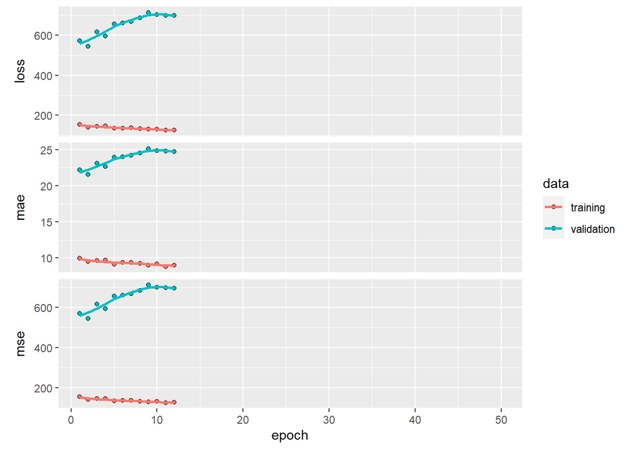

```r
plot(history)
```

Lembrando que os resultados de nikola_jokic com o modelo de Random_Forest treinado tinha métricas de RMSE = 6.57 e RSQ = 28.77, logo chego a conclusão de que analisar levando em consideração o tempo, não esteja rendendo bons resultados.

O modelo sarimax do auto.arima teve resultados mais significativos que as redes neurais. Isso me leva a dois pensamentos: - Menos é mais - Eu possivelmente fiz algo errado nas redes neurais